# 2. Define the Network Architecture

## Define the Convolutional Neural Network

After you've looked at the data you're working with and, in this case, know the shapes of the images and of the keypoints, you are ready to define a convolutional neural network that can *learn* from this data.

In this notebook and in `models.py`, you will:

1. Define a CNN with images as input and keypoints as output
2. Construct the transformed FaceKeypointsDataset, just as before
3. Train the CNN on the training data, tracking loss
4. See how the trained model performs on test data
5. If necessary, modify the CNN structure and model hyperparameters, so that it performs *well* *

* What does *well* mean?

"Well" means that the model's loss decreases during training **and**, when applied to test image data, the model produces keypoints that closely match the true keypoints of each face. And you'll see examples of this later in the notebook.

## CNN Architecture

Recall that CNN's are defined by a few types of layers:

- Convolutional layers
- Maxpooling layers
- Fully-connected layers

You are required to use the above layers and encouraged to add multiple convolutional layers and things like dropout layers that may prevent overfitting. You are also encouraged to look at literature on keypoint detection, such as [this paper](https://arxiv.org/pdf/1710.00977.pdf), to help you determine the structure of your network.

### TODO: Define your model in the provided file `models.py` file

This file is mostly empty but contains the expected name and some TODO's for creating your model.

## PyTorch Neural Nets

To define a neural network in PyTorch, you define the layers of a model in the function `__init__` and define the feedforward behavior of a network that employs those initialized layers in the function `forward`, which takes in an input image tensor, `x`. The structure of this Net class is shown below and left for you to fill in.

Note: During training, PyTorch will be able to perform backpropagation by keeping track of the network's feedforward behavior and using autograd to calculate the update to the weights in the network.

#### Define the Layers in `__init__`

As a reminder, a conv/pool layer may be defined like this (in `__init__`):

```
# 1 input image channel (for grayscale images), 32 output channels/feature maps, 3x3 square convolution kernel
self.conv1 = nn.Conv2d(1, 32, 3)

# maxpool that uses a square window of kernel_size=2, stride=2
self.pool = nn.MaxPool2d(2, 2)
```

#### Refer to Layers in `forward`

Then referred to in the `forward` function like this, in which the conv1 layer has a ReLu activation applied to it before maxpooling is applied:

```
x = self.pool(F.relu(self.conv1(x)))
```

Best practice is to place any layers whose weights will change during the training process in `__init__` and refer to them in the `forward` function; any layers or functions that always behave in the same way, such as a pre-defined activation function, should appear *only* in the `forward` function.

#### Why models.py

You are tasked with defining the network in the `models.py` file so that any models you define can be saved and loaded by name in different notebooks in this project directory. For example, by defining a CNN class called `Net` in `models.py`, you can then create that same architecture in this and other notebooks by simply importing the class and instantiating a model:

```
    from models import Net
    net = Net()
```

```python
# load the data if you need to; if you have already loaded the data, you may comment this cell out
# -- DO NOT CHANGE THIS CELL -- #
!mkdir /data
!wget -P /data/ https://s3.amazonaws.com/video.udacity-data.com/topher/2018/May/5aea1b91_train-test-data/train-test-data.zip
!unzip -n /data/train-test-data.zip -d /data
```

[output not shown]

[output cut: 5731 more lines]

[output not shown]

**Note:** Workspaces automatically close connections after 30 minutes of inactivity (including inactivity while training!). Use the code snippet below to keep your workspace alive during training. (The active_session context manager is imported below.)

```
from workspace_utils import active_session

with active_session():
    train_model(num_epochs)
```

```python
# import the usual resources
import matplotlib.pyplot as plt
import numpy as np

# import utilities to keep workspaces alive during model training
from workspace_utils import active_session

# watch for any changes in model.py, if it changes, re-load it automatically
%load_ext autoreload
%autoreload 2
```

```
The autoreload extension is already loaded. To reload it, use:
  %reload_ext autoreload
```

```python
## TODO: Define the Net in models.py

import torch
import torch.nn as nn
import torch.nn.functional as F

## TODO: Once you've define the network, you can instantiate it
# one example conv layer has been provided for you
from models import Net

net = Net()
print(net)
```

```
Net(
  (conv1): Conv2d(1, 32, kernel_size=(5, 5), stride=(1, 1))
  (conv2): Conv2d(32, 64, kernel_size=(5, 5), stride=(1, 1))
  (conv3): Conv2d(64, 128, kernel_size=(5, 5), stride=(1, 1))
  (conv4): Conv2d(128, 256, kernel_size=(5, 5), stride=(1, 1))
  (conv5): Conv2d(256, 512, kernel_size=(5, 5), stride=(1, 1))
  (fc1): Linear(in_features=4608, out_features=500, bias=True)
  (fc2): Linear(in_features=500, out_features=250, bias=True)
  (fc3): Linear(in_features=250, out_features=136, bias=True)
  (pool): MaxPool2d(kernel_size=2, stride=2, padding=0, dilation=1, ceil_mode=False)
  (fc1_drop): Dropout(p=0.5)
)
```

## Transform the dataset

To prepare for training, create a transformed dataset of images and keypoints.

### TODO: Define a data transform

In PyTorch, a convolutional neural network expects a torch image of a consistent size as input. For efficient training, and so your model's loss does not blow up during training, it is also suggested that you normalize the input images and keypoints. The necessary transforms have been defined in `data_load.py` and you **do not** need to modify these; take a look at this file (you'll see the same transforms that were defined and applied in Notebook 1).

To define the data transform below, use a [composition](http://pytorch.org/tutorials/beginner/data_loading_tutorial.html#compose-transforms) of:

1. Rescaling and/or cropping the data, such that you are left with a square image (the suggested size is 224x224px)
2. Normalizing the images and keypoints; turning each RGB image into a grayscale image with a color range of [0, 1] and transforming the given keypoints into a range of [-1, 1]
3. Turning these images and keypoints into Tensors

These transformations have been defined in `data_load.py`, but it's up to you to call them and create a `data_transform` below. **This transform will be applied to the training data and, later, the test data**. It will change how you go about displaying these images and keypoints, but these steps are essential for efficient training.

As a note, should you want to perform data augmentation (which is optional in this project), and randomly rotate or shift these images, a square image size will be useful; rotating a 224x224 image by 90 degrees will result in the same shape of output.

```python
from torch.utils.data import Dataset, DataLoader
from torchvision import transforms, utils

# the dataset we created in Notebook 1 is copied in the helper file `data_load.py`
from data_load import FacialKeypointsDataset
# the transforms we defined in Notebook 1 are in the helper file `data_load.py`
from data_load import Rescale, RandomCrop, Normalize, ToTensor


## TODO: define the data_transform using transforms.Compose([all tx's, . , .])
# order matters! i.e. rescaling should come before a smaller crop
data_transform = transforms.Compose([Rescale(250),
                                     RandomCrop(224),
                                     Normalize(),
                                     ToTensor()])

# testing that you've defined a transform
assert(data_transform is not None), 'Define a data_transform'
```

```python
# create the transformed dataset
transformed_dataset = FacialKeypointsDataset(csv_file='/data/training_frames_keypoints.csv',
                                             root_dir='/data/training/',
                                             transform=data_transform)


print('Number of images: ', len(transformed_dataset))

# iterate through the transformed dataset and print some stats about the first few samples
for i in range(4):
    sample = transformed_dataset[i]
    print(i, sample['image'].size(), sample['keypoints'].size())
```

```
Number of images:  3462
0 torch.Size([1, 224, 224]) torch.Size([68, 2])
1 torch.Size([1, 224, 224]) torch.Size([68, 2])
2 torch.Size([1, 224, 224]) torch.Size([68, 2])
3 torch.Size([1, 224, 224]) torch.Size([68, 2])
```

## Batching and loading data

Next, having defined the transformed dataset, we can use PyTorch's DataLoader class to load the training data in batches of whatever size as well as to shuffle the data for training the model. You can read more about the parameters of the DataLoader, in [this documentation](http://pytorch.org/docs/master/data.html).

#### Batch size

Decide on a good batch size for training your model. Try both small and large batch sizes and note how the loss decreases as the model trains. Too large a batch size may cause your model to crash and/or run out of memory while training.

**Note for Windows users**: Please change the `num_workers` to 0 or you may face some issues with your DataLoader failing.

```python
# load training data in batches
batch_size = 10

train_loader = DataLoader(transformed_dataset,
                          batch_size=batch_size,
                          shuffle=True,
                          num_workers=6)
```

## Before training

Take a look at how this model performs before it trains. You should see that the keypoints it predicts start off in one spot and don't match the keypoints on a face at all! It's interesting to visualize this behavior so that you can compare it to the model after training and see how the model has improved.

#### Load in the test dataset

The test dataset is one that this model has *not* seen before, meaning it has not trained with these images. We'll load in this test data and before and after training, see how your model performs on this set!

To visualize this test data, we have to go through some un-transformation steps to turn our images into python images from tensors and to turn our keypoints back into a recognizable range.

```python
# load in the test data, using the dataset class
# AND apply the data_transform you defined above

# create the test dataset
test_dataset = FacialKeypointsDataset(csv_file='/data/test_frames_keypoints.csv',
                                             root_dir='/data/test/',
                                             transform=data_transform)
```

```python
# load test data in batches
batch_size = 10

test_loader = DataLoader(test_dataset,
                          batch_size=batch_size,
                          shuffle=True,
                          num_workers=6)
```

## Apply the model on a test sample

To test the model on a test sample of data, you have to follow these steps:

1. Extract the image and ground truth keypoints from a sample
2. Wrap the image in a Variable, so that the net can process it as input and track how it changes as the image moves through the network.
3. Make sure the image is a FloatTensor, which the model expects.
4. Forward pass the image through the net to get the predicted, output keypoints.

This function test how the network performs on the first batch of test data. It returns the images, the transformed images, the predicted keypoints (produced by the model), and the ground truth keypoints.

```python
# test the model on a batch of test images

def net_sample_output():

    # iterate through the test dataset
    for i, sample in enumerate(test_loader):

        # get sample data: images and ground truth keypoints
        images = sample['image']
        key_pts = sample['keypoints']

        # convert images to FloatTensors
        images = images.type(torch.FloatTensor)

        # forward pass to get net output
        output_pts = net(images)

        # reshape to batch_size x 68 x 2 pts
        output_pts = output_pts.view(output_pts.size()[0], 68, -1)

        # break after first image is tested
        if i == 0:
            return images, output_pts, key_pts
```

#### Debugging tips

If you get a size or dimension error here, make sure that your network outputs the expected number of keypoints! Or if you get a Tensor type error, look into changing the above code that casts the data into float types: `images = images.type(torch.FloatTensor)`.

```python
# call the above function
# returns: test images, test predicted keypoints, test ground truth keypoints
test_images, test_outputs, gt_pts = net_sample_output()

# print out the dimensions of the data to see if they make sense
print(test_images.data.size())
print(test_outputs.data.size())
print(gt_pts.size())
```

```
torch.Size([10, 1, 224, 224])
torch.Size([10, 68, 2])
torch.Size([10, 68, 2])
```

## Visualize the predicted keypoints

Once we've had the model produce some predicted output keypoints, we can visualize these points in a way that's similar to how we've displayed this data before, only this time, we have to "un-transform" the image/keypoint data to display it.

Note that I've defined a *new* function, `show_all_keypoints` that displays a grayscale image, its predicted keypoints and its ground truth keypoints (if provided).

```python
def show_all_keypoints(image, predicted_key_pts, gt_pts=None):
    """Show image with predicted keypoints"""
    # image is grayscale
    plt.imshow(image, cmap='gray')
    plt.scatter(predicted_key_pts[:, 0], predicted_key_pts[:, 1], s=20, marker='.', c='m')
    # plot ground truth points as green pts
    if gt_pts is not None:
        plt.scatter(gt_pts[:, 0], gt_pts[:, 1], s=20, marker='.', c='g')
```

#### Un-transformation

Next, you'll see a helper function. `visualize_output` that takes in a batch of images, predicted keypoints, and ground truth keypoints and displays a set of those images and their true/predicted keypoints.

This function's main role is to take batches of image and keypoint data (the input and output of your CNN), and transform them into numpy images and un-normalized keypoints (x, y) for normal display. The un-transformation process turns keypoints and images into numpy arrays from Tensors *and* it undoes the keypoint normalization done in the Normalize() transform; it's assumed that you applied these transformations when you loaded your test data.

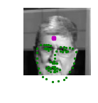

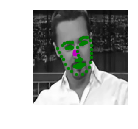

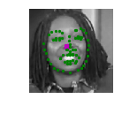

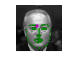

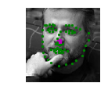

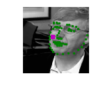

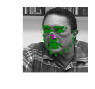

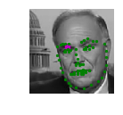

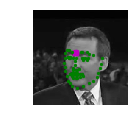

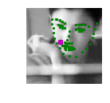

```python
# visualize the output
# by default this shows a batch of 10 images
def visualize_output(test_images, test_outputs, gt_pts=None, batch_size=10):

    for i in range(batch_size):
        plt.figure(figsize=(20,10))
        ax = plt.subplot(1, batch_size, i+1)

        # un-transform the image data
        image = test_images[i].data   # get the image from it's Variable wrapper
        image = image.numpy()   # convert to numpy array from a Tensor
        image = np.transpose(image, (1, 2, 0))   # transpose to go from torch to numpy image

        # un-transform the predicted key_pts data
        predicted_key_pts = test_outputs[i].data
        predicted_key_pts = predicted_key_pts.numpy()
        # undo normalization of keypoints
        predicted_key_pts = predicted_key_pts*50.0+100

        # plot ground truth points for comparison, if they exist
        ground_truth_pts = None
        if gt_pts is not None:
            ground_truth_pts = gt_pts[i]
            ground_truth_pts = ground_truth_pts*50.0+100

        # call show_all_keypoints
        show_all_keypoints(np.squeeze(image), predicted_key_pts, ground_truth_pts)

        plt.axis('off')

    plt.show()

# call it
visualize_output(test_images, test_outputs, gt_pts)
```

## Training

#### Loss function

Training a network to predict keypoints is different than training a network to predict a class; instead of outputting a distribution of classes and using cross entropy loss, you may want to choose a loss function that is suited for regression, which directly compares a predicted value and target value. Read about the various kinds of loss functions (like MSE or L1/SmoothL1 loss) in [this documentation](http://pytorch.org/docs/master/_modules/torch/nn/modules/loss.html).

### TODO: Define the loss and optimization

Next, you'll define how the model will train by deciding on the loss function and optimizer.

```python
## TODO: Define the loss and optimization
import torch.optim as optim

criterion = torch.nn.MSELoss()

optimizer = optim.Adam(net.parameters(), lr=0.0001)
```

## Training and Initial Observation

Now, you'll train on your batched training data from `train_loader` for a number of epochs.

To quickly observe how your model is training and decide on whether or not you should modify it's structure or hyperparameters, you're encouraged to start off with just one or two epochs at first. As you train, note how your the model's loss behaves over time: does it decrease quickly at first and then slow down? Does it take a while to decrease in the first place? What happens if you change the batch size of your training data or modify your loss function? etc.

Use these initial observations to make changes to your model and decide on the best architecture before you train for many epochs and create a final model.

```python
def train_net(n_epochs, device):

    # prepare the net for training
    net.to(device)
    net.train()

    # track loss
    loss_over_time = []

    for epoch in range(n_epochs):  # loop over the dataset multiple times

        running_loss = 0.0

        # train on batches of data, assumes you already have train_loader
        for batch_i, data in enumerate(train_loader):
            # get the input images and their corresponding labels


            images = data['image'].to(device)
            key_pts = data['keypoints'].to(device)

            # flatten pts
            key_pts = key_pts.view(key_pts.size(0), -1)

            # convert variables to floats for regression loss
            if device == 'cuda':
                key_pts = key_pts.type(torch.cuda.FloatTensor)
                images = images.type(torch.cuda.FloatTensor)
            else:
                key_pts = key_pts.type(torch.FloatTensor)
                images = images.type(torch.FloatTensor)

            # forward pass to get outputs
            output_pts = net(images)

            # calculate the loss between predicted and target keypoints
            loss = criterion(output_pts, key_pts)

            # zero the parameter (weight) gradients
            optimizer.zero_grad()

            # backward pass to calculate the weight gradients
            loss.backward()

            # update the weights

            optimizer.step()

            # print loss statistics
            running_loss += loss.item()
            if batch_i % 10 == 9:    # print every 10 batches
                avg_loss = running_loss/10
                loss_over_time.append(avg_loss)
                print('Epoch: {}, Batch: {}, Avg. Loss: {}'.format(epoch + 1, batch_i+1, avg_loss))
                running_loss = 0.0

    print('Finished Training')
    return loss_over_time
```

```python
import timeit

# device = torch.device("cuda" if torch.cuda.is_available() else "cpu")

# train your network
n_epochs = 40 # start small, and increase when you've decided on your model structure and hyperparams

start_time = timeit.default_timer()

# this is a Workspaces-specific context manager to keep the connection
# alive while training your model, not part of pytorch
with active_session():
    training_loss = train_net(n_epochs, 'cpu')

elapsed = (timeit.default_timer() - start_time)/60

print('Time (in minutes) for training:', round(elapsed, 2))
```

```
Epoch: 1, Batch: 10, Avg. Loss: 0.5480896145105362
Epoch: 1, Batch: 20, Avg. Loss: 0.5080726683139801
Epoch: 1, Batch: 30, Avg. Loss: 0.4695653676986694
Epoch: 1, Batch: 40, Avg. Loss: 0.433977410197258
Epoch: 1, Batch: 50, Avg. Loss: 0.40755838751792905
Epoch: 1, Batch: 60, Avg. Loss: 0.3217081218957901
Epoch: 1, Batch: 70, Avg. Loss: 0.3346722811460495
Epoch: 1, Batch: 80, Avg. Loss: 0.26446620672941207
Epoch: 1, Batch: 90, Avg. Loss: 0.29874932318925856
Epoch: 1, Batch: 100, Avg. Loss: 0.29046696573495867
Epoch: 1, Batch: 110, Avg. Loss: 0.3054493010044098
Epoch: 1, Batch: 120, Avg. Loss: 0.28806035220623016
Epoch: 1, Batch: 130, Avg. Loss: 0.25738250464200974
Epoch: 1, Batch: 140, Avg. Loss: 0.2415662631392479
Epoch: 1, Batch: 150, Avg. Loss: 0.29121632874011993
Epoch: 1, Batch: 160, Avg. Loss: 0.25101395696401596
Epoch: 1, Batch: 170, Avg. Loss: 0.29528726935386657
Epoch: 1, Batch: 180, Avg. Loss: 0.2954713597893715
Epoch: 1, Batch: 190, Avg. Loss: 0.23643676340579986
Epoch: 1, Batch: 200, Avg. Loss: 0.2351653516292572
Epoch: 1, Batch: 210, Avg. Loss: 0.29301791191101073
Epoch: 1, Batch: 220, Avg. Loss: 0.21563107520341873
Epoch: 1, Batch: 230, Avg. Loss: 0.21787057369947432
Epoch: 1, Batch: 240, Avg. Loss: 0.27241785228252413
Epoch: 1, Batch: 250, Avg. Loss: 0.22563114985823632
Epoch: 1, Batch: 260, Avg. Loss: 0.2596775949001312
Epoch: 1, Batch: 270, Avg. Loss: 0.24588499814271927
Epoch: 1, Batch: 280, Avg. Loss: 0.19828898161649705
Epoch: 1, Batch: 290, Avg. Loss: 0.23251825273036958
Epoch: 1, Batch: 300, Avg. Loss: 0.2251013286411762
Epoch: 1, Batch: 310, Avg. Loss: 0.30362381637096403
Epoch: 1, Batch: 320, Avg. Loss: 0.20579697638750077
Epoch: 1, Batch: 330, Avg. Loss: 0.2167445093393326
Epoch: 1, Batch: 340, Avg. Loss: 0.39798077940940857
```

```
Epoch: 2, Batch: 10, Avg. Loss: 0.23876563757658004
Epoch: 2, Batch: 20, Avg. Loss: 0.22304162979125977
Epoch: 2, Batch: 30, Avg. Loss: 0.2185510091483593
Epoch: 2, Batch: 40, Avg. Loss: 0.18971318006515503
Epoch: 2, Batch: 50, Avg. Loss: 0.19998079389333726
Epoch: 2, Batch: 60, Avg. Loss: 0.25271374434232713
Epoch: 2, Batch: 70, Avg. Loss: 0.23630744963884354
Epoch: 2, Batch: 80, Avg. Loss: 0.20610556825995446
Epoch: 2, Batch: 90, Avg. Loss: 0.19973507821559905
Epoch: 2, Batch: 100, Avg. Loss: 0.23437027633190155
Epoch: 2, Batch: 110, Avg. Loss: 0.2315238893032074
Epoch: 2, Batch: 120, Avg. Loss: 0.20810310989618303
Epoch: 2, Batch: 130, Avg. Loss: 0.1993133880198002
Epoch: 2, Batch: 140, Avg. Loss: 0.16659048050642014
Epoch: 2, Batch: 150, Avg. Loss: 0.20215571001172067
Epoch: 2, Batch: 160, Avg. Loss: 0.20500535666942596
Epoch: 2, Batch: 170, Avg. Loss: 0.1779193788766861
Epoch: 2, Batch: 180, Avg. Loss: 0.21105228066444398
Epoch: 2, Batch: 190, Avg. Loss: 0.29112656265497205
Epoch: 2, Batch: 200, Avg. Loss: 0.19570639729499817
Epoch: 2, Batch: 210, Avg. Loss: 0.22639898508787154
Epoch: 2, Batch: 220, Avg. Loss: 0.26028110533952714
Epoch: 2, Batch: 230, Avg. Loss: 0.18425947576761245
Epoch: 2, Batch: 240, Avg. Loss: 0.20290511399507521
Epoch: 2, Batch: 250, Avg. Loss: 0.19037313610315323
Epoch: 2, Batch: 260, Avg. Loss: 0.19989608377218246
Epoch: 2, Batch: 270, Avg. Loss: 0.21082482635974883
Epoch: 2, Batch: 280, Avg. Loss: 0.19882735311985017
Epoch: 2, Batch: 290, Avg. Loss: 0.2823394015431404
Epoch: 2, Batch: 300, Avg. Loss: 0.20858699083328247
Epoch: 2, Batch: 310, Avg. Loss: 0.20620066076517105
Epoch: 2, Batch: 320, Avg. Loss: 0.1820130877196789
Epoch: 2, Batch: 330, Avg. Loss: 0.22604130804538727
Epoch: 2, Batch: 340, Avg. Loss: 0.22195687443017958
```

```
Epoch: 3, Batch: 10, Avg. Loss: 0.3391000688076019
Epoch: 3, Batch: 20, Avg. Loss: 0.18105184733867646
Epoch: 3, Batch: 30, Avg. Loss: 0.16585085019469262
Epoch: 3, Batch: 40, Avg. Loss: 0.18558520823717117
Epoch: 3, Batch: 50, Avg. Loss: 0.22382114008069037
Epoch: 3, Batch: 60, Avg. Loss: 0.2038773477077484
Epoch: 3, Batch: 70, Avg. Loss: 0.22117270305752754
Epoch: 3, Batch: 80, Avg. Loss: 0.17598338425159454
Epoch: 3, Batch: 90, Avg. Loss: 0.18230436444282533
Epoch: 3, Batch: 100, Avg. Loss: 0.2013821095228195
Epoch: 3, Batch: 110, Avg. Loss: 0.1888095274567604
Epoch: 3, Batch: 120, Avg. Loss: 0.17431829646229743
Epoch: 3, Batch: 130, Avg. Loss: 0.1926766261458397
Epoch: 3, Batch: 140, Avg. Loss: 0.21935672014951707
Epoch: 3, Batch: 150, Avg. Loss: 0.315012601017952
Epoch: 3, Batch: 160, Avg. Loss: 0.21492696255445481
Epoch: 3, Batch: 170, Avg. Loss: 0.21574986279010772
Epoch: 3, Batch: 180, Avg. Loss: 0.18499953672289848
Epoch: 3, Batch: 190, Avg. Loss: 0.18150064572691918
Epoch: 3, Batch: 200, Avg. Loss: 0.26124871224164964
Epoch: 3, Batch: 210, Avg. Loss: 0.17952705621719361
Epoch: 3, Batch: 220, Avg. Loss: 0.16607927829027175
Epoch: 3, Batch: 230, Avg. Loss: 0.1805608868598938
Epoch: 3, Batch: 240, Avg. Loss: 0.17128425016999244
Epoch: 3, Batch: 250, Avg. Loss: 0.20166971161961555
Epoch: 3, Batch: 260, Avg. Loss: 0.2477683275938034
Epoch: 3, Batch: 270, Avg. Loss: 0.2403651088476181
Epoch: 3, Batch: 280, Avg. Loss: 0.15958494395017625
Epoch: 3, Batch: 290, Avg. Loss: 0.18994286879897118
Epoch: 3, Batch: 300, Avg. Loss: 0.21771729737520218
Epoch: 3, Batch: 310, Avg. Loss: 0.18736109063029288
Epoch: 3, Batch: 320, Avg. Loss: 0.18257336392998696
Epoch: 3, Batch: 330, Avg. Loss: 0.18394809514284133
Epoch: 3, Batch: 340, Avg. Loss: 0.19213736206293106
```

```
Epoch: 4, Batch: 10, Avg. Loss: 0.173369675129652
Epoch: 4, Batch: 20, Avg. Loss: 0.19753651916980744
Epoch: 4, Batch: 30, Avg. Loss: 0.20298482924699784
Epoch: 4, Batch: 40, Avg. Loss: 0.16183070465922356
Epoch: 4, Batch: 50, Avg. Loss: 0.185719034075737
Epoch: 4, Batch: 60, Avg. Loss: 0.20030386745929718
Epoch: 4, Batch: 70, Avg. Loss: 0.20086781084537506
Epoch: 4, Batch: 80, Avg. Loss: 0.16719102188944818
Epoch: 4, Batch: 90, Avg. Loss: 0.18192467018961905
Epoch: 4, Batch: 100, Avg. Loss: 0.19493558928370475
Epoch: 4, Batch: 110, Avg. Loss: 0.33931137472391126
Epoch: 4, Batch: 120, Avg. Loss: 0.16731794625520707
Epoch: 4, Batch: 130, Avg. Loss: 0.16211540028452873
Epoch: 4, Batch: 140, Avg. Loss: 0.2174015834927559
Epoch: 4, Batch: 150, Avg. Loss: 0.23690769225358962
Epoch: 4, Batch: 160, Avg. Loss: 0.21999746561050415
Epoch: 4, Batch: 170, Avg. Loss: 0.18927208259701728
Epoch: 4, Batch: 180, Avg. Loss: 0.18205147087574006
Epoch: 4, Batch: 190, Avg. Loss: 0.19209694787859916
Epoch: 4, Batch: 200, Avg. Loss: 0.15204465985298157
Epoch: 4, Batch: 210, Avg. Loss: 0.20862334296107293
Epoch: 4, Batch: 220, Avg. Loss: 0.2267269417643547
Epoch: 4, Batch: 230, Avg. Loss: 0.1412355422973633
Epoch: 4, Batch: 240, Avg. Loss: 0.16073497906327247
Epoch: 4, Batch: 250, Avg. Loss: 0.1410099245607853
Epoch: 4, Batch: 260, Avg. Loss: 0.14881071746349334
Epoch: 4, Batch: 270, Avg. Loss: 0.14368524625897408
Epoch: 4, Batch: 280, Avg. Loss: 0.2123052164912224
Epoch: 4, Batch: 290, Avg. Loss: 0.21620174422860144
Epoch: 4, Batch: 300, Avg. Loss: 0.18744439706206323
Epoch: 4, Batch: 310, Avg. Loss: 0.15839474648237228
Epoch: 4, Batch: 320, Avg. Loss: 0.20707278326153755
Epoch: 4, Batch: 330, Avg. Loss: 0.1521912097930908
Epoch: 4, Batch: 340, Avg. Loss: 0.1927693583071232
```

```
Epoch: 5, Batch: 10, Avg. Loss: 0.15716801658272744
Epoch: 5, Batch: 20, Avg. Loss: 0.19967015087604523
Epoch: 5, Batch: 30, Avg. Loss: 0.15933689773082732
Epoch: 5, Batch: 40, Avg. Loss: 0.15349244996905326
Epoch: 5, Batch: 50, Avg. Loss: 0.24565078280866146
Epoch: 5, Batch: 60, Avg. Loss: 0.16793047040700912
Epoch: 5, Batch: 70, Avg. Loss: 0.1616402819752693
Epoch: 5, Batch: 80, Avg. Loss: 0.13956114575266837
Epoch: 5, Batch: 90, Avg. Loss: 0.15484669134020806
Epoch: 5, Batch: 100, Avg. Loss: 0.14118427336215972
Epoch: 5, Batch: 110, Avg. Loss: 0.15150784850120544
Epoch: 5, Batch: 120, Avg. Loss: 0.1771027125418186
Epoch: 5, Batch: 130, Avg. Loss: 0.11879365146160126
Epoch: 5, Batch: 140, Avg. Loss: 0.1307763583958149
Epoch: 5, Batch: 150, Avg. Loss: 0.11974952965974808
Epoch: 5, Batch: 160, Avg. Loss: 0.12810520753264426
Epoch: 5, Batch: 170, Avg. Loss: 0.10621091276407242
Epoch: 5, Batch: 180, Avg. Loss: 0.3284547716379166
Epoch: 5, Batch: 190, Avg. Loss: 0.12237663045525551
Epoch: 5, Batch: 200, Avg. Loss: 0.14844324439764023
Epoch: 5, Batch: 210, Avg. Loss: 0.10983514189720153
Epoch: 5, Batch: 220, Avg. Loss: 0.121306774020195
Epoch: 5, Batch: 230, Avg. Loss: 0.1548749715089798
Epoch: 5, Batch: 240, Avg. Loss: 0.10974490270018578
Epoch: 5, Batch: 250, Avg. Loss: 0.0966449610888958
Epoch: 5, Batch: 260, Avg. Loss: 0.12943088375031947
Epoch: 5, Batch: 270, Avg. Loss: 0.1602768886834383
Epoch: 5, Batch: 280, Avg. Loss: 0.11611111834645271
Epoch: 5, Batch: 290, Avg. Loss: 0.13221795186400415
Epoch: 5, Batch: 300, Avg. Loss: 0.11590077094733715
Epoch: 5, Batch: 310, Avg. Loss: 0.11965818703174591
Epoch: 5, Batch: 320, Avg. Loss: 0.10217727050185203
Epoch: 5, Batch: 330, Avg. Loss: 0.11977058723568916
Epoch: 5, Batch: 340, Avg. Loss: 0.14185255728662013
```

```
Epoch: 6, Batch: 10, Avg. Loss: 0.17122255079448223
Epoch: 6, Batch: 20, Avg. Loss: 0.08967413604259492
Epoch: 6, Batch: 30, Avg. Loss: 0.10876201950013638
Epoch: 6, Batch: 40, Avg. Loss: 0.09199563153088093
Epoch: 6, Batch: 50, Avg. Loss: 0.11581258550286293
Epoch: 6, Batch: 60, Avg. Loss: 0.09175289645791054
Epoch: 6, Batch: 70, Avg. Loss: 0.09169291332364082
Epoch: 6, Batch: 80, Avg. Loss: 0.10986010991036892
Epoch: 6, Batch: 90, Avg. Loss: 0.09670015722513199
Epoch: 6, Batch: 100, Avg. Loss: 0.18109390512108803
Epoch: 6, Batch: 110, Avg. Loss: 0.09421130754053593
Epoch: 6, Batch: 120, Avg. Loss: 0.09533248543739319
Epoch: 6, Batch: 130, Avg. Loss: 0.09524007849395275
Epoch: 6, Batch: 140, Avg. Loss: 0.10613662265241146
Epoch: 6, Batch: 150, Avg. Loss: 0.0852042056620121
Epoch: 6, Batch: 160, Avg. Loss: 0.08155672661960126
Epoch: 6, Batch: 170, Avg. Loss: 0.09023952223360539
Epoch: 6, Batch: 180, Avg. Loss: 0.07484362684190274
Epoch: 6, Batch: 190, Avg. Loss: 0.08116934560239315
Epoch: 6, Batch: 200, Avg. Loss: 0.08279358223080635
Epoch: 6, Batch: 210, Avg. Loss: 0.09629092738032341
Epoch: 6, Batch: 220, Avg. Loss: 0.0593094140291214
Epoch: 6, Batch: 230, Avg. Loss: 0.07301286906003952
Epoch: 6, Batch: 240, Avg. Loss: 0.10221625193953514
Epoch: 6, Batch: 250, Avg. Loss: 0.10607465542852879
Epoch: 6, Batch: 260, Avg. Loss: 0.11069928407669068
Epoch: 6, Batch: 270, Avg. Loss: 0.06333921998739242
Epoch: 6, Batch: 280, Avg. Loss: 0.09897001944482327
Epoch: 6, Batch: 290, Avg. Loss: 0.08399526178836822
Epoch: 6, Batch: 300, Avg. Loss: 0.08349997363984585
Epoch: 6, Batch: 310, Avg. Loss: 0.11132361367344856
Epoch: 6, Batch: 320, Avg. Loss: 0.07517547011375428
Epoch: 6, Batch: 330, Avg. Loss: 0.07266818284988404
Epoch: 6, Batch: 340, Avg. Loss: 0.0699736762791872
```

```
Epoch: 7, Batch: 10, Avg. Loss: 0.08226679265499115
Epoch: 7, Batch: 20, Avg. Loss: 0.0942450299859047
Epoch: 7, Batch: 30, Avg. Loss: 0.10649341344833374
Epoch: 7, Batch: 40, Avg. Loss: 0.12593111731112003
Epoch: 7, Batch: 50, Avg. Loss: 0.07340691164135933
Epoch: 7, Batch: 60, Avg. Loss: 0.06901611350476741
Epoch: 7, Batch: 70, Avg. Loss: 0.07412738278508187
Epoch: 7, Batch: 80, Avg. Loss: 0.05546188950538635
Epoch: 7, Batch: 90, Avg. Loss: 0.06485694199800492
Epoch: 7, Batch: 100, Avg. Loss: 0.1352013036608696
Epoch: 7, Batch: 110, Avg. Loss: 0.06658505350351333
Epoch: 7, Batch: 120, Avg. Loss: 0.10888921171426773
Epoch: 7, Batch: 130, Avg. Loss: 0.0632349792867899
Epoch: 7, Batch: 140, Avg. Loss: 0.09073581881821155
Epoch: 7, Batch: 150, Avg. Loss: 0.0686030387878418
Epoch: 7, Batch: 160, Avg. Loss: 0.0656689528375864
Epoch: 7, Batch: 170, Avg. Loss: 0.06322559230029583
Epoch: 7, Batch: 180, Avg. Loss: 0.1253841884434223
Epoch: 7, Batch: 190, Avg. Loss: 0.09590634405612945
Epoch: 7, Batch: 200, Avg. Loss: 0.07584258392453194
Epoch: 7, Batch: 210, Avg. Loss: 0.09353871010243893
Epoch: 7, Batch: 220, Avg. Loss: 0.09196893312036991
Epoch: 7, Batch: 230, Avg. Loss: 0.07468019351363182
Epoch: 7, Batch: 240, Avg. Loss: 0.08056941442191601
Epoch: 7, Batch: 250, Avg. Loss: 0.08501438423991203
Epoch: 7, Batch: 260, Avg. Loss: 0.05559043772518635
Epoch: 7, Batch: 270, Avg. Loss: 0.07121430113911628
Epoch: 7, Batch: 280, Avg. Loss: 0.06742166168987751
Epoch: 7, Batch: 290, Avg. Loss: 0.07107281610369683
Epoch: 7, Batch: 300, Avg. Loss: 0.1364658832550049
Epoch: 7, Batch: 310, Avg. Loss: 0.08408373072743416
Epoch: 7, Batch: 320, Avg. Loss: 0.08021164461970329
Epoch: 7, Batch: 330, Avg. Loss: 0.08073670454323292
Epoch: 7, Batch: 340, Avg. Loss: 0.05440103560686112
```

```
Epoch: 8, Batch: 10, Avg. Loss: 0.06062609739601612
Epoch: 8, Batch: 20, Avg. Loss: 0.0668529823422432
Epoch: 8, Batch: 30, Avg. Loss: 0.053246534615755084
Epoch: 8, Batch: 40, Avg. Loss: 0.06881338208913804
Epoch: 8, Batch: 50, Avg. Loss: 0.05773717500269413
Epoch: 8, Batch: 60, Avg. Loss: 0.05169289447367191
Epoch: 8, Batch: 70, Avg. Loss: 0.047444986179471016
Epoch: 8, Batch: 80, Avg. Loss: 0.10356470122933388
Epoch: 8, Batch: 90, Avg. Loss: 0.06407953538000584
Epoch: 8, Batch: 100, Avg. Loss: 0.0712105680257082
Epoch: 8, Batch: 110, Avg. Loss: 0.08415566012263298
Epoch: 8, Batch: 120, Avg. Loss: 0.06993465647101402
Epoch: 8, Batch: 130, Avg. Loss: 0.06849428974092006
Epoch: 8, Batch: 140, Avg. Loss: 0.07761576361954212
Epoch: 8, Batch: 150, Avg. Loss: 0.0807819563895464
Epoch: 8, Batch: 160, Avg. Loss: 0.06133670285344124
Epoch: 8, Batch: 170, Avg. Loss: 0.08805711194872856
Epoch: 8, Batch: 180, Avg. Loss: 0.05249892994761467
Epoch: 8, Batch: 190, Avg. Loss: 0.08932864516973496
Epoch: 8, Batch: 200, Avg. Loss: 0.07530771791934968
Epoch: 8, Batch: 210, Avg. Loss: 0.10816538333892822
Epoch: 8, Batch: 220, Avg. Loss: 0.0742786854505539
Epoch: 8, Batch: 230, Avg. Loss: 0.13683608956635
Epoch: 8, Batch: 240, Avg. Loss: 0.07571678720414639
Epoch: 8, Batch: 250, Avg. Loss: 0.1323775600641966
Epoch: 8, Batch: 260, Avg. Loss: 0.07614414542913436
Epoch: 8, Batch: 270, Avg. Loss: 0.07901602238416672
Epoch: 8, Batch: 280, Avg. Loss: 0.07123511433601379
Epoch: 8, Batch: 290, Avg. Loss: 0.07584397010505199
Epoch: 8, Batch: 300, Avg. Loss: 0.11671646833419799
Epoch: 8, Batch: 310, Avg. Loss: 0.10332126170396805
Epoch: 8, Batch: 320, Avg. Loss: 0.06662725359201431
Epoch: 8, Batch: 330, Avg. Loss: 0.07572120353579521
Epoch: 8, Batch: 340, Avg. Loss: 0.0668143380433321
```

```
Epoch: 9, Batch: 10, Avg. Loss: 0.06712426394224166
Epoch: 9, Batch: 20, Avg. Loss: 0.074214918166399
Epoch: 9, Batch: 30, Avg. Loss: 0.06143548376858234
Epoch: 9, Batch: 40, Avg. Loss: 0.06774002946913242
Epoch: 9, Batch: 50, Avg. Loss: 0.05847739428281784
Epoch: 9, Batch: 60, Avg. Loss: 0.07235272638499737
Epoch: 9, Batch: 70, Avg. Loss: 0.07223381996154785
Epoch: 9, Batch: 80, Avg. Loss: 0.05592918023467064
Epoch: 9, Batch: 90, Avg. Loss: 0.054367194697260854
Epoch: 9, Batch: 100, Avg. Loss: 0.05355552136898041
Epoch: 9, Batch: 110, Avg. Loss: 0.056942108646035196
Epoch: 9, Batch: 120, Avg. Loss: 0.06050536148250103
Epoch: 9, Batch: 130, Avg. Loss: 0.06176967397332191
Epoch: 9, Batch: 140, Avg. Loss: 0.04945363439619541
Epoch: 9, Batch: 150, Avg. Loss: 0.05398450270295143
Epoch: 9, Batch: 160, Avg. Loss: 0.05067134443670511
Epoch: 9, Batch: 170, Avg. Loss: 0.05771118402481079
Epoch: 9, Batch: 180, Avg. Loss: 0.06667927429080009
Epoch: 9, Batch: 190, Avg. Loss: 0.07317688912153245
Epoch: 9, Batch: 200, Avg. Loss: 0.05619923081248999
Epoch: 9, Batch: 210, Avg. Loss: 0.10201348811388015
Epoch: 9, Batch: 220, Avg. Loss: 0.0623271994292736
Epoch: 9, Batch: 230, Avg. Loss: 0.10067997053265572
Epoch: 9, Batch: 240, Avg. Loss: 0.059939884766936305
Epoch: 9, Batch: 250, Avg. Loss: 0.09360955730080604
Epoch: 9, Batch: 260, Avg. Loss: 0.07556596510112286
Epoch: 9, Batch: 270, Avg. Loss: 0.059821512550115585
Epoch: 9, Batch: 280, Avg. Loss: 0.06869189143180847
Epoch: 9, Batch: 290, Avg. Loss: 0.06821957975625992
Epoch: 9, Batch: 300, Avg. Loss: 0.06967516876757145
Epoch: 9, Batch: 310, Avg. Loss: 0.07208402529358864
Epoch: 9, Batch: 320, Avg. Loss: 0.09494509212672711
Epoch: 9, Batch: 330, Avg. Loss: 0.055513618513941765
Epoch: 9, Batch: 340, Avg. Loss: 0.0996832549571991
```

```
Epoch: 10, Batch: 10, Avg. Loss: 0.04652151092886925
Epoch: 10, Batch: 20, Avg. Loss: 0.05764226820319891
Epoch: 10, Batch: 30, Avg. Loss: 0.052658993378281595
Epoch: 10, Batch: 40, Avg. Loss: 0.1116731509566307
Epoch: 10, Batch: 50, Avg. Loss: 0.05057327300310135
Epoch: 10, Batch: 60, Avg. Loss: 0.09019905142486095
Epoch: 10, Batch: 70, Avg. Loss: 0.045704571157693864
Epoch: 10, Batch: 80, Avg. Loss: 0.05662775430828333
Epoch: 10, Batch: 90, Avg. Loss: 0.060568392649292944
Epoch: 10, Batch: 100, Avg. Loss: 0.05022411793470383
Epoch: 10, Batch: 110, Avg. Loss: 0.05188321247696877
Epoch: 10, Batch: 120, Avg. Loss: 0.050880714878439905
Epoch: 10, Batch: 130, Avg. Loss: 0.04189138989895582
Epoch: 10, Batch: 140, Avg. Loss: 0.06122218482196331
Epoch: 10, Batch: 150, Avg. Loss: 0.039191348291933534
Epoch: 10, Batch: 160, Avg. Loss: 0.04677411951124668
Epoch: 10, Batch: 170, Avg. Loss: 0.07556088529527187
Epoch: 10, Batch: 180, Avg. Loss: 0.07880220636725425
Epoch: 10, Batch: 190, Avg. Loss: 0.08757415190339088
Epoch: 10, Batch: 200, Avg. Loss: 0.06916140466928482
Epoch: 10, Batch: 210, Avg. Loss: 0.05264013223350048
Epoch: 10, Batch: 220, Avg. Loss: 0.06616795361042023
Epoch: 10, Batch: 230, Avg. Loss: 0.055641553923487665
Epoch: 10, Batch: 240, Avg. Loss: 0.05038433242589235
Epoch: 10, Batch: 250, Avg. Loss: 0.06430394276976585
Epoch: 10, Batch: 260, Avg. Loss: 0.06204120311886072
Epoch: 10, Batch: 270, Avg. Loss: 0.06750596687197685
Epoch: 10, Batch: 280, Avg. Loss: 0.0544922661036253
Epoch: 10, Batch: 290, Avg. Loss: 0.08108965270221233
Epoch: 10, Batch: 300, Avg. Loss: 0.1115255180746317
Epoch: 10, Batch: 310, Avg. Loss: 0.049218620359897616
Epoch: 10, Batch: 320, Avg. Loss: 0.0995292317122221
Epoch: 10, Batch: 330, Avg. Loss: 0.044325859658420085
Epoch: 10, Batch: 340, Avg. Loss: 0.04915688559412956
```

```
Epoch: 11, Batch: 10, Avg. Loss: 0.06361551769077778
Epoch: 11, Batch: 20, Avg. Loss: 0.04745010007172823
Epoch: 11, Batch: 30, Avg. Loss: 0.04550347663462162
Epoch: 11, Batch: 40, Avg. Loss: 0.038212848082184794
Epoch: 11, Batch: 50, Avg. Loss: 0.0440185546875
Epoch: 11, Batch: 60, Avg. Loss: 0.03650141917169094
Epoch: 11, Batch: 70, Avg. Loss: 0.04915287867188454
Epoch: 11, Batch: 80, Avg. Loss: 0.04288452286273241
Epoch: 11, Batch: 90, Avg. Loss: 0.042119793221354486
Epoch: 11, Batch: 100, Avg. Loss: 0.04454080946743488
Epoch: 11, Batch: 110, Avg. Loss: 0.04952414352446795
Epoch: 11, Batch: 120, Avg. Loss: 0.0599082961678505
Epoch: 11, Batch: 130, Avg. Loss: 0.05815544500946999
Epoch: 11, Batch: 140, Avg. Loss: 0.050696777366101745
Epoch: 11, Batch: 150, Avg. Loss: 0.046727625839412215
Epoch: 11, Batch: 160, Avg. Loss: 0.042135536298155786
Epoch: 11, Batch: 170, Avg. Loss: 0.045769048109650615
Epoch: 11, Batch: 180, Avg. Loss: 0.05151291936635971
Epoch: 11, Batch: 190, Avg. Loss: 0.04629279971122742
Epoch: 11, Batch: 200, Avg. Loss: 0.059905231930315495
Epoch: 11, Batch: 210, Avg. Loss: 0.1320463091135025
Epoch: 11, Batch: 220, Avg. Loss: 0.04915369413793087
Epoch: 11, Batch: 230, Avg. Loss: 0.07932281699031592
Epoch: 11, Batch: 240, Avg. Loss: 0.039328782632946965
Epoch: 11, Batch: 250, Avg. Loss: 0.047235305234789846
Epoch: 11, Batch: 260, Avg. Loss: 0.05741833057254553
Epoch: 11, Batch: 270, Avg. Loss: 0.08704167306423187
Epoch: 11, Batch: 280, Avg. Loss: 0.06416986882686615
Epoch: 11, Batch: 290, Avg. Loss: 0.09316496513783931
Epoch: 11, Batch: 300, Avg. Loss: 0.062138667330145836
Epoch: 11, Batch: 310, Avg. Loss: 0.053514550626277926
Epoch: 11, Batch: 320, Avg. Loss: 0.06107451170682907
Epoch: 11, Batch: 330, Avg. Loss: 0.0498348381370306
Epoch: 11, Batch: 340, Avg. Loss: 0.08175493255257607
```

```
Epoch: 12, Batch: 10, Avg. Loss: 0.043837514519691465
Epoch: 12, Batch: 20, Avg. Loss: 0.04846784844994545
Epoch: 12, Batch: 30, Avg. Loss: 0.06296548396348953
Epoch: 12, Batch: 40, Avg. Loss: 0.0395406324416399
Epoch: 12, Batch: 50, Avg. Loss: 0.04615516476333141
Epoch: 12, Batch: 60, Avg. Loss: 0.06151326354593038
Epoch: 12, Batch: 70, Avg. Loss: 0.056615672633051874
Epoch: 12, Batch: 80, Avg. Loss: 0.04850412048399448
Epoch: 12, Batch: 90, Avg. Loss: 0.0561828063800931
Epoch: 12, Batch: 100, Avg. Loss: 0.04388565868139267
Epoch: 12, Batch: 110, Avg. Loss: 0.0614174909889698
Epoch: 12, Batch: 120, Avg. Loss: 0.04279397055506706
Epoch: 12, Batch: 130, Avg. Loss: 0.04427610747516155
Epoch: 12, Batch: 140, Avg. Loss: 0.07121026255190373
Epoch: 12, Batch: 150, Avg. Loss: 0.05464257821440697
Epoch: 12, Batch: 160, Avg. Loss: 0.04348032623529434
Epoch: 12, Batch: 170, Avg. Loss: 0.04516054056584835
Epoch: 12, Batch: 180, Avg. Loss: 0.04315683655440807
Epoch: 12, Batch: 190, Avg. Loss: 0.04459067303687334
Epoch: 12, Batch: 200, Avg. Loss: 0.0437841285020113
Epoch: 12, Batch: 210, Avg. Loss: 0.0560724850744009
Epoch: 12, Batch: 220, Avg. Loss: 0.04817856773734093
Epoch: 12, Batch: 230, Avg. Loss: 0.041791504621505736
Epoch: 12, Batch: 240, Avg. Loss: 0.053042779117822646
Epoch: 12, Batch: 250, Avg. Loss: 0.051849051378667355
Epoch: 12, Batch: 260, Avg. Loss: 0.14183936696499586
Epoch: 12, Batch: 270, Avg. Loss: 0.058646752312779424
Epoch: 12, Batch: 280, Avg. Loss: 0.049842600151896475
Epoch: 12, Batch: 290, Avg. Loss: 0.04467115812003612
Epoch: 12, Batch: 300, Avg. Loss: 0.05173282474279404
Epoch: 12, Batch: 310, Avg. Loss: 0.07446901351213456
Epoch: 12, Batch: 320, Avg. Loss: 0.04911807365715504
Epoch: 12, Batch: 330, Avg. Loss: 0.06954561434686184
Epoch: 12, Batch: 340, Avg. Loss: 0.08681921400129795
```

```
Epoch: 13, Batch: 10, Avg. Loss: 0.04601372089236975
Epoch: 13, Batch: 20, Avg. Loss: 0.04158170986920595
Epoch: 13, Batch: 30, Avg. Loss: 0.04308868441730738
Epoch: 13, Batch: 40, Avg. Loss: 0.048572849668562415
Epoch: 13, Batch: 50, Avg. Loss: 0.06279410403221845
Epoch: 13, Batch: 60, Avg. Loss: 0.04538905639201403
Epoch: 13, Batch: 70, Avg. Loss: 0.06685549803078175
Epoch: 13, Batch: 80, Avg. Loss: 0.05095843877643347
Epoch: 13, Batch: 90, Avg. Loss: 0.0383569672703743
Epoch: 13, Batch: 100, Avg. Loss: 0.039983393624424934
Epoch: 13, Batch: 110, Avg. Loss: 0.04829122200608253
Epoch: 13, Batch: 120, Avg. Loss: 0.048187438026070596
Epoch: 13, Batch: 130, Avg. Loss: 0.04178097061812878
Epoch: 13, Batch: 140, Avg. Loss: 0.04559768307954073
Epoch: 13, Batch: 150, Avg. Loss: 0.09080256372690201
Epoch: 13, Batch: 160, Avg. Loss: 0.03991459496319294
Epoch: 13, Batch: 170, Avg. Loss: 0.048705192655324935
Epoch: 13, Batch: 180, Avg. Loss: 0.04603588972240687
Epoch: 13, Batch: 190, Avg. Loss: 0.0420651014894247
Epoch: 13, Batch: 200, Avg. Loss: 0.04743363857269287
Epoch: 13, Batch: 210, Avg. Loss: 0.04742909073829651
Epoch: 13, Batch: 220, Avg. Loss: 0.03528278507292271
Epoch: 13, Batch: 230, Avg. Loss: 0.05616881623864174
Epoch: 13, Batch: 240, Avg. Loss: 0.07071426101028919
Epoch: 13, Batch: 250, Avg. Loss: 0.054438921995460986
Epoch: 13, Batch: 260, Avg. Loss: 0.0581809788942337
Epoch: 13, Batch: 270, Avg. Loss: 0.046566522866487506
Epoch: 13, Batch: 280, Avg. Loss: 0.0695861641317606
Epoch: 13, Batch: 290, Avg. Loss: 0.04850736763328314
Epoch: 13, Batch: 300, Avg. Loss: 0.04318906646221876
Epoch: 13, Batch: 310, Avg. Loss: 0.04445817284286022
Epoch: 13, Batch: 320, Avg. Loss: 0.2863610967993736
Epoch: 13, Batch: 330, Avg. Loss: 0.04714277815073729
Epoch: 13, Batch: 340, Avg. Loss: 0.047794369608163835
```

```
Epoch: 14, Batch: 10, Avg. Loss: 0.05421538539230823
Epoch: 14, Batch: 20, Avg. Loss: 0.08945408128201962
Epoch: 14, Batch: 30, Avg. Loss: 0.06401263624429702
Epoch: 14, Batch: 40, Avg. Loss: 0.06003257483243942
Epoch: 14, Batch: 50, Avg. Loss: 0.04309502802789211
Epoch: 14, Batch: 60, Avg. Loss: 0.04295248668640852
Epoch: 14, Batch: 70, Avg. Loss: 0.057813132926821706
Epoch: 14, Batch: 80, Avg. Loss: 0.14224471822381018
Epoch: 14, Batch: 90, Avg. Loss: 0.07195507790893316
Epoch: 14, Batch: 100, Avg. Loss: 0.04983111452311277
Epoch: 14, Batch: 110, Avg. Loss: 0.048182780295610426
Epoch: 14, Batch: 120, Avg. Loss: 0.040709457360208035
Epoch: 14, Batch: 130, Avg. Loss: 0.03547276724129915
Epoch: 14, Batch: 140, Avg. Loss: 0.053805281221866605
Epoch: 14, Batch: 150, Avg. Loss: 0.03464615475386381
Epoch: 14, Batch: 160, Avg. Loss: 0.11713146474212408
Epoch: 14, Batch: 170, Avg. Loss: 0.04438168406486511
Epoch: 14, Batch: 180, Avg. Loss: 0.04243613854050636
Epoch: 14, Batch: 190, Avg. Loss: 0.05455362647771835
Epoch: 14, Batch: 200, Avg. Loss: 0.047709772177040574
Epoch: 14, Batch: 210, Avg. Loss: 0.03815553653985262
Epoch: 14, Batch: 220, Avg. Loss: 0.051000604405999184
Epoch: 14, Batch: 230, Avg. Loss: 0.03711309395730496
Epoch: 14, Batch: 240, Avg. Loss: 0.0643265776336193
Epoch: 14, Batch: 250, Avg. Loss: 0.052442540787160395
Epoch: 14, Batch: 260, Avg. Loss: 0.040995058789849284
Epoch: 14, Batch: 270, Avg. Loss: 0.08846710808575153
Epoch: 14, Batch: 280, Avg. Loss: 0.05810053795576096
Epoch: 14, Batch: 290, Avg. Loss: 0.0635289117693901
Epoch: 14, Batch: 300, Avg. Loss: 0.12404636275023222
Epoch: 14, Batch: 310, Avg. Loss: 0.11294843591749668
Epoch: 14, Batch: 320, Avg. Loss: 0.04262801632285118
Epoch: 14, Batch: 330, Avg. Loss: 0.036252842657268046
Epoch: 14, Batch: 340, Avg. Loss: 0.059833765774965283
```

```
Epoch: 15, Batch: 10, Avg. Loss: 0.06878855694085359
Epoch: 15, Batch: 20, Avg. Loss: 0.040687527507543564
Epoch: 15, Batch: 30, Avg. Loss: 0.049213522113859653
Epoch: 15, Batch: 40, Avg. Loss: 0.04312670510262251
Epoch: 15, Batch: 50, Avg. Loss: 0.046790843829512596
Epoch: 15, Batch: 60, Avg. Loss: 0.04875602126121521
Epoch: 15, Batch: 70, Avg. Loss: 0.0389767486602068
Epoch: 15, Batch: 80, Avg. Loss: 0.04603370185941458
Epoch: 15, Batch: 90, Avg. Loss: 0.038148516230285166
Epoch: 15, Batch: 100, Avg. Loss: 0.05015844814479351
Epoch: 15, Batch: 110, Avg. Loss: 0.042574507370591166
Epoch: 15, Batch: 120, Avg. Loss: 0.04468659553676844
Epoch: 15, Batch: 130, Avg. Loss: 0.04280800558626652
Epoch: 15, Batch: 140, Avg. Loss: 0.04381211064755917
Epoch: 15, Batch: 150, Avg. Loss: 0.03878621943295002
Epoch: 15, Batch: 160, Avg. Loss: 0.03856679983437061
Epoch: 15, Batch: 170, Avg. Loss: 0.044064865447580814
Epoch: 15, Batch: 180, Avg. Loss: 0.044616959430277346
Epoch: 15, Batch: 190, Avg. Loss: 0.04682261664420366
Epoch: 15, Batch: 200, Avg. Loss: 0.04247040450572968
Epoch: 15, Batch: 210, Avg. Loss: 0.03499481864273548
Epoch: 15, Batch: 220, Avg. Loss: 0.04903666116297245
Epoch: 15, Batch: 230, Avg. Loss: 0.04244651608169079
Epoch: 15, Batch: 240, Avg. Loss: 0.03955457378178835
Epoch: 15, Batch: 250, Avg. Loss: 0.05765970777720213
Epoch: 15, Batch: 260, Avg. Loss: 0.04763855841010809
Epoch: 15, Batch: 270, Avg. Loss: 0.042577086761593816
Epoch: 15, Batch: 280, Avg. Loss: 0.047149849496781825
Epoch: 15, Batch: 290, Avg. Loss: 0.0369817266240716
Epoch: 15, Batch: 300, Avg. Loss: 0.04552113451063633
Epoch: 15, Batch: 310, Avg. Loss: 0.05382385589182377
Epoch: 15, Batch: 320, Avg. Loss: 0.03537132181227207
Epoch: 15, Batch: 330, Avg. Loss: 0.03639660496264696
Epoch: 15, Batch: 340, Avg. Loss: 0.03843454569578171
```

```
Epoch: 16, Batch: 10, Avg. Loss: 0.04336092583835125
Epoch: 16, Batch: 20, Avg. Loss: 0.046618517488241196
Epoch: 16, Batch: 30, Avg. Loss: 0.059000519849359986
Epoch: 16, Batch: 40, Avg. Loss: 0.03773786500096321
Epoch: 16, Batch: 50, Avg. Loss: 0.050423449091613295
Epoch: 16, Batch: 60, Avg. Loss: 0.05221748240292072
Epoch: 16, Batch: 70, Avg. Loss: 0.04207230322062969
Epoch: 16, Batch: 80, Avg. Loss: 0.04599735997617245
Epoch: 16, Batch: 90, Avg. Loss: 0.04793011248111725
Epoch: 16, Batch: 100, Avg. Loss: 0.03877208847552538
Epoch: 16, Batch: 110, Avg. Loss: 0.048467057198286055
Epoch: 16, Batch: 120, Avg. Loss: 0.07094292342662811
Epoch: 16, Batch: 130, Avg. Loss: 0.035202824510633945
Epoch: 16, Batch: 140, Avg. Loss: 0.04049532413482666
Epoch: 16, Batch: 150, Avg. Loss: 0.03608057126402855
Epoch: 16, Batch: 160, Avg. Loss: 0.0334814727306366
Epoch: 16, Batch: 170, Avg. Loss: 0.03612081557512283
Epoch: 16, Batch: 180, Avg. Loss: 0.048060514591634275
Epoch: 16, Batch: 190, Avg. Loss: 0.044847124628722666
Epoch: 16, Batch: 200, Avg. Loss: 0.03303063195198774
Epoch: 16, Batch: 210, Avg. Loss: 0.037358741834759714
Epoch: 16, Batch: 220, Avg. Loss: 0.032340949214994905
Epoch: 16, Batch: 230, Avg. Loss: 0.1003664257004857
Epoch: 16, Batch: 240, Avg. Loss: 0.04205411858856678
Epoch: 16, Batch: 250, Avg. Loss: 0.04520178642123938
Epoch: 16, Batch: 260, Avg. Loss: 0.062466489523649214
Epoch: 16, Batch: 270, Avg. Loss: 0.04995928592979908
Epoch: 16, Batch: 280, Avg. Loss: 0.047583440132439134
Epoch: 16, Batch: 290, Avg. Loss: 0.042788808420300486
Epoch: 16, Batch: 300, Avg. Loss: 0.06742090452462435
Epoch: 16, Batch: 310, Avg. Loss: 0.038412288576364514
Epoch: 16, Batch: 320, Avg. Loss: 0.04404508080333471
Epoch: 16, Batch: 330, Avg. Loss: 0.04014051780104637
Epoch: 16, Batch: 340, Avg. Loss: 0.04492989033460617
```

```
Epoch: 17, Batch: 10, Avg. Loss: 0.05107985958456993
Epoch: 17, Batch: 20, Avg. Loss: 0.041669049113988874
Epoch: 17, Batch: 30, Avg. Loss: 0.04085149560123682
Epoch: 17, Batch: 40, Avg. Loss: 0.031092401407659054
Epoch: 17, Batch: 50, Avg. Loss: 0.03724732175469399
Epoch: 17, Batch: 60, Avg. Loss: 0.03932292144745588
Epoch: 17, Batch: 70, Avg. Loss: 0.03211045786738396
Epoch: 17, Batch: 80, Avg. Loss: 0.0355024429038167
Epoch: 17, Batch: 90, Avg. Loss: 0.036796729639172555
Epoch: 17, Batch: 100, Avg. Loss: 0.03678206466138363
Epoch: 17, Batch: 110, Avg. Loss: 0.042548143118619916
Epoch: 17, Batch: 120, Avg. Loss: 0.04641018006950617
Epoch: 17, Batch: 130, Avg. Loss: 0.04768335912376642
Epoch: 17, Batch: 140, Avg. Loss: 0.04851968735456467
Epoch: 17, Batch: 150, Avg. Loss: 0.04515731874853372
Epoch: 17, Batch: 160, Avg. Loss: 0.03753514811396599
Epoch: 17, Batch: 170, Avg. Loss: 0.038210099935531615
Epoch: 17, Batch: 180, Avg. Loss: 0.08343956917524338
Epoch: 17, Batch: 190, Avg. Loss: 0.08554173652082682
Epoch: 17, Batch: 200, Avg. Loss: 0.04296947307884693
Epoch: 17, Batch: 210, Avg. Loss: 0.041171137057244775
Epoch: 17, Batch: 220, Avg. Loss: 0.042532878927886486
Epoch: 17, Batch: 230, Avg. Loss: 0.03268761225044727
Epoch: 17, Batch: 240, Avg. Loss: 0.04780374728143215
Epoch: 17, Batch: 250, Avg. Loss: 0.03984182346612215
Epoch: 17, Batch: 260, Avg. Loss: 0.046909219771623614
Epoch: 17, Batch: 270, Avg. Loss: 0.058826544880867006
Epoch: 17, Batch: 280, Avg. Loss: 0.044131221063435075
Epoch: 17, Batch: 290, Avg. Loss: 0.0388149119913578
Epoch: 17, Batch: 300, Avg. Loss: 0.047178168408572675
Epoch: 17, Batch: 310, Avg. Loss: 0.03781692441552877
Epoch: 17, Batch: 320, Avg. Loss: 0.048298434168100354
Epoch: 17, Batch: 330, Avg. Loss: 0.03899586237967014
Epoch: 17, Batch: 340, Avg. Loss: 0.036909866519272326
```

```
Epoch: 18, Batch: 10, Avg. Loss: 0.028149786032736303
Epoch: 18, Batch: 20, Avg. Loss: 0.04310647547245026
Epoch: 18, Batch: 30, Avg. Loss: 0.0824363747611642
Epoch: 18, Batch: 40, Avg. Loss: 0.04581125937402249
Epoch: 18, Batch: 50, Avg. Loss: 0.0433651065453887
Epoch: 18, Batch: 60, Avg. Loss: 0.03572142533957958
Epoch: 18, Batch: 70, Avg. Loss: 0.03656607884913683
Epoch: 18, Batch: 80, Avg. Loss: 0.08430818393826485
Epoch: 18, Batch: 90, Avg. Loss: 0.057206761091947556
Epoch: 18, Batch: 100, Avg. Loss: 0.04507196545600891
Epoch: 18, Batch: 110, Avg. Loss: 0.047667845338582995
Epoch: 18, Batch: 120, Avg. Loss: 0.03698248229920864
Epoch: 18, Batch: 130, Avg. Loss: 0.03861805982887745
Epoch: 18, Batch: 140, Avg. Loss: 0.03753568157553673
Epoch: 18, Batch: 150, Avg. Loss: 0.06093280706554651
Epoch: 18, Batch: 160, Avg. Loss: 0.038213218562304974
Epoch: 18, Batch: 170, Avg. Loss: 0.04417300410568714
Epoch: 18, Batch: 180, Avg. Loss: 0.08654677551239728
Epoch: 18, Batch: 190, Avg. Loss: 0.044788917899131774
Epoch: 18, Batch: 200, Avg. Loss: 0.03911058995872736
Epoch: 18, Batch: 210, Avg. Loss: 0.0385101605206728
Epoch: 18, Batch: 220, Avg. Loss: 0.0830413181334734
Epoch: 18, Batch: 230, Avg. Loss: 0.06568373031914235
Epoch: 18, Batch: 240, Avg. Loss: 0.047244342789053914
Epoch: 18, Batch: 250, Avg. Loss: 0.04094299804419279
Epoch: 18, Batch: 260, Avg. Loss: 0.03205267395824194
Epoch: 18, Batch: 270, Avg. Loss: 0.03995886519551277
Epoch: 18, Batch: 280, Avg. Loss: 0.047594170458614825
Epoch: 18, Batch: 290, Avg. Loss: 0.03378615416586399
Epoch: 18, Batch: 300, Avg. Loss: 0.04752289354801178
Epoch: 18, Batch: 310, Avg. Loss: 0.032479787990450856
Epoch: 18, Batch: 320, Avg. Loss: 0.04390907883644104
Epoch: 18, Batch: 330, Avg. Loss: 0.031130782887339593
Epoch: 18, Batch: 340, Avg. Loss: 0.032821481488645075
```

```
Epoch: 19, Batch: 10, Avg. Loss: 0.037433304265141486
Epoch: 19, Batch: 20, Avg. Loss: 0.05264014359563589
Epoch: 19, Batch: 30, Avg. Loss: 0.03429839573800564
Epoch: 19, Batch: 40, Avg. Loss: 0.03347262162715196
Epoch: 19, Batch: 50, Avg. Loss: 0.04799945410341024
Epoch: 19, Batch: 60, Avg. Loss: 0.030430789291858672
Epoch: 19, Batch: 70, Avg. Loss: 0.035522624477744104
Epoch: 19, Batch: 80, Avg. Loss: 0.033902314677834514
Epoch: 19, Batch: 90, Avg. Loss: 0.06343983095139265
Epoch: 19, Batch: 100, Avg. Loss: 0.036687956750392915
Epoch: 19, Batch: 110, Avg. Loss: 0.03465036656707525
Epoch: 19, Batch: 120, Avg. Loss: 0.03540947809815407
Epoch: 19, Batch: 130, Avg. Loss: 0.04679665584117174
Epoch: 19, Batch: 140, Avg. Loss: 0.06210329346358776
Epoch: 19, Batch: 150, Avg. Loss: 0.03319333400577307
Epoch: 19, Batch: 160, Avg. Loss: 0.09324711468070745
Epoch: 19, Batch: 170, Avg. Loss: 0.03631238080561161
Epoch: 19, Batch: 180, Avg. Loss: 0.04477374758571386
Epoch: 19, Batch: 190, Avg. Loss: 0.04320904966443777
Epoch: 19, Batch: 200, Avg. Loss: 0.035765393171459436
Epoch: 19, Batch: 210, Avg. Loss: 0.04428073614835739
Epoch: 19, Batch: 220, Avg. Loss: 0.04425217043608427
Epoch: 19, Batch: 230, Avg. Loss: 0.06410565171390772
Epoch: 19, Batch: 240, Avg. Loss: 0.035619272477924825
Epoch: 19, Batch: 250, Avg. Loss: 0.034781058132648465
Epoch: 19, Batch: 260, Avg. Loss: 0.03238134551793337
Epoch: 19, Batch: 270, Avg. Loss: 0.04100640472024679
Epoch: 19, Batch: 280, Avg. Loss: 0.030861425586044787
Epoch: 19, Batch: 290, Avg. Loss: 0.03574065025895834
Epoch: 19, Batch: 300, Avg. Loss: 0.031741156801581384
Epoch: 19, Batch: 310, Avg. Loss: 0.03620242867618799
Epoch: 19, Batch: 320, Avg. Loss: 0.05568920951336622
Epoch: 19, Batch: 330, Avg. Loss: 0.03649201840162277
Epoch: 19, Batch: 340, Avg. Loss: 0.03329553510993719
```

```
Epoch: 20, Batch: 10, Avg. Loss: 0.03859301973134279
Epoch: 20, Batch: 20, Avg. Loss: 0.03354709651321173
Epoch: 20, Batch: 30, Avg. Loss: 0.033566980995237826
Epoch: 20, Batch: 40, Avg. Loss: 0.039064590074121955
Epoch: 20, Batch: 50, Avg. Loss: 0.05306915007531643
Epoch: 20, Batch: 60, Avg. Loss: 0.02933148518204689
Epoch: 20, Batch: 70, Avg. Loss: 0.03005714789032936
Epoch: 20, Batch: 80, Avg. Loss: 0.08246104307472706
Epoch: 20, Batch: 90, Avg. Loss: 0.03040074687451124
Epoch: 20, Batch: 100, Avg. Loss: 0.041830402240157126
Epoch: 20, Batch: 110, Avg. Loss: 0.04429429676383734
Epoch: 20, Batch: 120, Avg. Loss: 0.040408484265208246
Epoch: 20, Batch: 130, Avg. Loss: 0.03068813160061836
Epoch: 20, Batch: 140, Avg. Loss: 0.03458915762603283
Epoch: 20, Batch: 150, Avg. Loss: 0.034743718802928925
Epoch: 20, Batch: 160, Avg. Loss: 0.064095026999712
Epoch: 20, Batch: 170, Avg. Loss: 0.03259210791438818
Epoch: 20, Batch: 180, Avg. Loss: 0.0355747252702713
Epoch: 20, Batch: 190, Avg. Loss: 0.07420413326472045
Epoch: 20, Batch: 200, Avg. Loss: 0.038439614325761796
Epoch: 20, Batch: 210, Avg. Loss: 0.03940865602344275
Epoch: 20, Batch: 220, Avg. Loss: 0.03613707628101111
Epoch: 20, Batch: 230, Avg. Loss: 0.15541038382798433
Epoch: 20, Batch: 240, Avg. Loss: 0.03586110435426235
Epoch: 20, Batch: 250, Avg. Loss: 0.03577153589576483
Epoch: 20, Batch: 260, Avg. Loss: 0.054065588302910327
Epoch: 20, Batch: 270, Avg. Loss: 0.037200598418712615
Epoch: 20, Batch: 280, Avg. Loss: 0.03265650141984224
Epoch: 20, Batch: 290, Avg. Loss: 0.074072059802711
Epoch: 20, Batch: 300, Avg. Loss: 0.04010322298854589
Epoch: 20, Batch: 310, Avg. Loss: 0.03729180321097374
Epoch: 20, Batch: 320, Avg. Loss: 0.10617918781936168
Epoch: 20, Batch: 330, Avg. Loss: 0.030682657659053803
Epoch: 20, Batch: 340, Avg. Loss: 0.03255504164844751
```

```
Epoch: 21, Batch: 10, Avg. Loss: 0.07412336524575949
Epoch: 21, Batch: 20, Avg. Loss: 0.036895678378641605
Epoch: 21, Batch: 30, Avg. Loss: 0.03956187143921852
Epoch: 21, Batch: 40, Avg. Loss: 0.04005448427051306
Epoch: 21, Batch: 50, Avg. Loss: 0.039501990750432016
Epoch: 21, Batch: 60, Avg. Loss: 0.03507338371127844
Epoch: 21, Batch: 70, Avg. Loss: 0.03401164151728153
Epoch: 21, Batch: 80, Avg. Loss: 0.04045038558542728
Epoch: 21, Batch: 90, Avg. Loss: 0.02915182672441006
Epoch: 21, Batch: 100, Avg. Loss: 0.034688199684023854
Epoch: 21, Batch: 110, Avg. Loss: 0.0319276150316
Epoch: 21, Batch: 120, Avg. Loss: 0.03954269159585237
Epoch: 21, Batch: 130, Avg. Loss: 0.03384449742734432
Epoch: 21, Batch: 140, Avg. Loss: 0.03394447900354862
Epoch: 21, Batch: 150, Avg. Loss: 0.03537648618221283
Epoch: 21, Batch: 160, Avg. Loss: 0.03487503919750452
Epoch: 21, Batch: 170, Avg. Loss: 0.04443962909281254
Epoch: 21, Batch: 180, Avg. Loss: 0.039361692033708096
Epoch: 21, Batch: 190, Avg. Loss: 0.028653696179389954
Epoch: 21, Batch: 200, Avg. Loss: 0.03489024490118027
Epoch: 21, Batch: 210, Avg. Loss: 0.0334020733833313
Epoch: 21, Batch: 220, Avg. Loss: 0.032053316943347454
Epoch: 21, Batch: 230, Avg. Loss: 0.03265005331486463
Epoch: 21, Batch: 240, Avg. Loss: 0.030450187996029852
Epoch: 21, Batch: 250, Avg. Loss: 0.0331489410251379
Epoch: 21, Batch: 260, Avg. Loss: 0.036709520034492016
Epoch: 21, Batch: 270, Avg. Loss: 0.03207001555711031
Epoch: 21, Batch: 280, Avg. Loss: 0.03312115427106619
Epoch: 21, Batch: 290, Avg. Loss: 0.0734212912619114
Epoch: 21, Batch: 300, Avg. Loss: 0.03231535684317351
Epoch: 21, Batch: 310, Avg. Loss: 0.058101273514330386
Epoch: 21, Batch: 320, Avg. Loss: 0.038797159306705
Epoch: 21, Batch: 330, Avg. Loss: 0.03090994171798229
Epoch: 21, Batch: 340, Avg. Loss: 0.03572965525090695
```

```
Epoch: 22, Batch: 10, Avg. Loss: 0.03137711249291897
Epoch: 22, Batch: 20, Avg. Loss: 0.059043405763804915
Epoch: 22, Batch: 30, Avg. Loss: 0.033697709813714026
Epoch: 22, Batch: 40, Avg. Loss: 0.039680339954793455
Epoch: 22, Batch: 50, Avg. Loss: 0.03596729189157486
Epoch: 22, Batch: 60, Avg. Loss: 0.05936846807599068
Epoch: 22, Batch: 70, Avg. Loss: 0.033107245527207854
Epoch: 22, Batch: 80, Avg. Loss: 0.042629783786833284
Epoch: 22, Batch: 90, Avg. Loss: 0.029436819441616534
Epoch: 22, Batch: 100, Avg. Loss: 0.033774872310459614
Epoch: 22, Batch: 110, Avg. Loss: 0.04741346724331379
Epoch: 22, Batch: 120, Avg. Loss: 0.03389380890876055
Epoch: 22, Batch: 130, Avg. Loss: 0.03526374958455562
Epoch: 22, Batch: 140, Avg. Loss: 0.03636236730962992
Epoch: 22, Batch: 150, Avg. Loss: 0.027833964116871356
Epoch: 22, Batch: 160, Avg. Loss: 0.03193994723260403
Epoch: 22, Batch: 170, Avg. Loss: 0.03964097686111927
Epoch: 22, Batch: 180, Avg. Loss: 0.028182119131088257
Epoch: 22, Batch: 190, Avg. Loss: 0.14852162171155214
Epoch: 22, Batch: 200, Avg. Loss: 0.031825852766633037
Epoch: 22, Batch: 210, Avg. Loss: 0.05141957364976406
Epoch: 22, Batch: 220, Avg. Loss: 0.028673922270536424
Epoch: 22, Batch: 230, Avg. Loss: 0.05899342577904463
Epoch: 22, Batch: 240, Avg. Loss: 0.03345424961298704
Epoch: 22, Batch: 250, Avg. Loss: 0.03536065984517336
Epoch: 22, Batch: 260, Avg. Loss: 0.033133250288665296
Epoch: 22, Batch: 270, Avg. Loss: 0.03920281492173672
Epoch: 22, Batch: 280, Avg. Loss: 0.08937009181827307
Epoch: 22, Batch: 290, Avg. Loss: 0.03797784186899662
Epoch: 22, Batch: 300, Avg. Loss: 0.043973347172141075
Epoch: 22, Batch: 310, Avg. Loss: 0.04856284465640783
Epoch: 22, Batch: 320, Avg. Loss: 0.09254163540899754
Epoch: 22, Batch: 330, Avg. Loss: 0.03832943756133318
Epoch: 22, Batch: 340, Avg. Loss: 0.042990820668637755
```

[output not shown]

[output not shown]

[output not shown]

[output not shown]

[output not shown]

[output not shown]

[output not shown]

[output not shown]

[output not shown]

[output not shown]

[output not shown]

[output not shown]

[output not shown]

[output not shown]

[output not shown]

[output not shown]

[output not shown]

[output not shown]

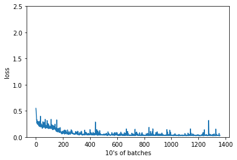

```python
# visualize the loss as the network trained
plt.plot(training_loss)
plt.xlabel('10\'s of batches')
plt.ylabel('loss')
plt.ylim(0, 2.5) # consistent scale
plt.show()
```

## Test data

See how your model performs on previously unseen, test data. We've already loaded and transformed this data, similar to the training data. Next, run your trained model on these images to see what kind of keypoints are produced. You should be able to see if your model is fitting each new face it sees, if the points are distributed randomly, or if the points have actually overfitted the training data and do not generalize.

```python
# get a sample of test data again
test_images, test_outputs, gt_pts = net_sample_output()

print(test_images.data.size())
print(test_outputs.data.size())
print(gt_pts.size())
```

[output not shown]

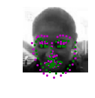

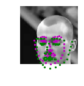

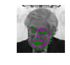

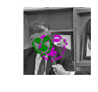

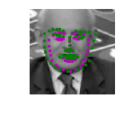

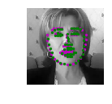

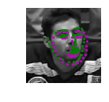

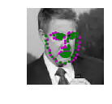

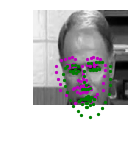

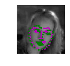

```python
## TODO: visualize your test output
# you can use the same function as before, by un-commenting the line below:

visualize_output(test_images, test_outputs, gt_pts)
```

Once you've found a good model (or two), save your model so you can load it and use it later!

Save your models but please **delete any checkpoints and saved models before you submit your project** otherwise your workspace may be too large to submit.

```python
## TODO: change the name to something uniqe for each new model
model_dir = 'saved_models/'
model_name = 'keypoints_model_1_32_64_128_256_512_wDrop50_0001.pt'

# after training, save your model parameters in the dir 'saved_models'
torch.save(net.state_dict(), model_dir+model_name)
```

After you've trained a well-performing model, answer the following questions so that we have some insight into your training and architecture selection process. Answering all questions is required to pass this project.

### Question 1: What optimization and loss functions did you choose and why?

**Answer**: Since this is a regression problem (trying to predict the x-y coordinates of the keypoints), I used Mean Squared Error (MSE) loss. Another options would have been Mean Squared Logarithmic Error and Mean Absolute Error loss but I decided to go with the default and it gave pretty good results. For optimizer I used Adam since in the past few years this has become a benchmark for many papers in many deep learning papers in general, and in NLP and computer vision in particular.

### Question 2: What kind of network architecture did you start with and how did it change as you tried different architectures? Did you decide to add more convolutional layers or any layers to avoid overfitting the data?

**Answer**: I first started with a relatively simple architecture with 3 convolutional layers with pooling between them, followed by 2 linear layers. I also used dropout between the layers (also between the convolutional layers). In general, the initial results were not too bad but there was clearly for improvement. Then I decided to add two more convolutional layers (to get 5 in total) and experimented with different learning rates (between 0.001 and 0.00001) and dropouts. Also removing the dropouts between the convolutional layers gave better results.

## Feature Visualization

Sometimes, neural networks are thought of as a black box, given some input, they learn to produce some output. CNN's are actually learning to recognize a variety of spatial patterns and you can visualize what each convolutional layer has been trained to recognize by looking at the weights that make up each convolutional kernel and applying those one at a time to a sample image. This technique is called feature visualization and it's useful for understanding the inner workings of a CNN.

In the cell below, you can see how to extract a single filter (by index) from your first convolutional layer. The filter should appear as a grayscale grid.

```
[[ 0.15731175 -0.01499213  0.16649586 -0.16672622 -0.0750399 ]
 [-0.1029235  -0.13041052 -0.06888252  0.19184814  0.03590473]
 [ 0.08603282 -0.18702452 -0.08013599  0.10355041 -0.14033332]
 [-0.19037786  0.05559022  0.12864834 -0.1570383  -0.14854003]
 [-0.10752956 -0.17066602 -0.02207708 -0.17272988 -0.07022595]]
(5, 5)
```

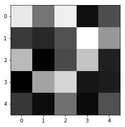

```python
# Get the weights in the first conv layer, "conv1"
# if necessary, change this to reflect the name of your first conv layer
weights1 = net.conv1.weight.data

w = weights1.numpy()

filter_index = 0

print(w[filter_index][0])
print(w[filter_index][0].shape)

# display the filter weights
plt.imshow(w[filter_index][0], cmap='gray');
```

## Feature maps

Each CNN has at least one convolutional layer that is composed of stacked filters (also known as convolutional kernels). As a CNN trains, it learns what weights to include in it's convolutional kernels and when these kernels are applied to some input image, they produce a set of **feature maps**. So, feature maps are just sets of filtered images; they are the images produced by applying a convolutional kernel to an input image. These maps show us the features that the different layers of the neural network learn to extract. For example, you might imagine a convolutional kernel that detects the vertical edges of a face or another one that detects the corners of eyes. You can see what kind of features each of these kernels detects by applying them to an image. One such example is shown below; from the way it brings out the lines in an the image, you might characterize this as an edge detection filter.

[figure not shown]

Next, choose a test image and filter it with one of the convolutional kernels in your trained CNN; look at the filtered output to get an idea what that particular kernel detects.

### TODO: Filter an image to see the effect of a convolutional kernel

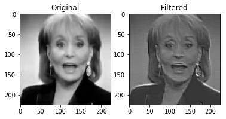

```python
##TODO: load in and display any image from the transformed test dataset
image = test_images[2].data
image = image.numpy()
image = np.squeeze(image)


## TODO: Using cv's filter2D function,
## apply a specific set of filter weights (like the one displayed above) to the test image

import cv2

weights = net.conv2.weight.data
w = weights.numpy()

fig, axes = plt.subplots(nrows=1, ncols=2)
axes[0].imshow(image, cmap='gray')
axes[0].set_title('Original')

c = cv2.filter2D(image, -1, w[4][0])
axes[1].imshow(c, cmap='gray')
axes[1].set_title('Filtered');
```

### Question 4: Choose one filter from your trained CNN and apply it to a test image; what purpose do you think it plays? What kind of feature do you think it detects?

**Answer**: Given the brightest spots in the filtered image are the shoulders, I think this filter detects horizontal lines.

# ---

## Moving on!

Now that you've defined and trained your model (and saved the best model), you are ready to move on to the last notebook, which combines a face detector with your saved model to create a facial keypoint detection system that can predict the keypoints on *any* face in an image!